# Capitulo 9 - Estadistica 2

# Ejercicio 1

Considere la prueba de hipótesis siguiente.

$$H_0: \mu \leq 12$$ $$H_a: \mu > 12 $$

En una muestra de 25, la media muestral es $ \bar{x} = 14 $ y la desviación estándar $s = 4.32 $.

a) **Calcule el valor del estadístico de prueba.**

b) **Use la tabla de distribución t (tabla 2 del apéndice B) a fin de calcular un intervalo para el valor-p.**

c) **Con $\alpha = 0.05 $, ¿cuál es su conclusión?**

d) **¿Cuál es la regla de rechazo usando el valor crítico? ¿Qué concluye?**

# Solución

**Inciso a)**

El estadístico de prueba \(t\) se calcula utilizando la fórmula:

$$ t = \frac{(\bar{x} - \mu_0)}{(s/\sqrt{n})} $$

Donde:

- $(\bar{x})$ es la media muestral,
- $(\mu_0)$ es la media bajo la hipótesis nula,
- $(s)$ es la desviación estándar muestral, y
- $(n)$ es el tamaño de la muestra.

En este caso: $$ t = \frac{(14 - 12)}{(4.32/\sqrt{25})} $$

**Inciso b)** Intervalo para el Valor-p:

**Inciso c)**

$(\alpha = 0.05)$:

Si el valor-p es menor que $(\alpha)$, rechazamos la hipótesis nula $((H_0))$.

**Inciso d)**

Rechazamos $(H_0)$ si $(t > t_{\text{crítico}})$.

**a)**

$$ t = \frac{(14 - 12)}{(4.32/\sqrt{25})} $$

**b)**

Usando la tabla de distribución t, encontramos $(t_{\text{crítico}})$ para $( \alpha/2 = 0.025 )$ con 24 grados de libertad.

**c)**

Compararemos el valor-p con $(\alpha)$ y decidiremos si rechazamos $(H_0)$.

**d)**

Rechazamos $(H_0)$ si $(t > t_{\text{crítico}})$.

FIGURA 9.1

Valores críticos en la prueba de hipótesis"

```python
import numpy as np
import matplotlib.pyplot as plt
from scipy.stats import norm

# Generar datos de la distribución muestral
x = np.linspace(0 - 1 * 2, 0 + 1 * 2, 1000)
y = norm.pdf(x*4, 0, 2)

# Crear la gráfica
fig, ax = plt.subplots()
ax.plot(x, y, color='#009929')

# Establecer el color de fondo
ax.set_facecolor('#d4f8b7')

# Pintar el fondo externo del gráfico
fig.patch.set_facecolor('#D4F8B7')

# Etiquetas y texto
ax.set_xlabel(f'$valor-p = 2(0.0630) = 0.1260$', fontsize=10)
ax.text(0.02, 0.15, r'P(z ≤ -1.53) = 0.0630', transform=ax.transAxes, fontsize=7.5, color='#000')
ax.text(0.76, 0.15, r'P(z ≥ 1.53) = 0.0630', transform=ax.transAxes, fontsize=7.5, color='#000')
ax.text(0.06, -0.11, r'-1.53', transform=ax.transAxes, fontsize=12, color='#000')
ax.text(0.86, -0.11, r'1.53', transform=ax.transAxes, fontsize=12, color='#000')

# Líneas verticales
for i in np.arange(0.02, 0.98, 0.02):
    ax.text(i, 0.01, r'|', transform=ax.transAxes, fontsize=12, color='#009929')

# Líneas horizontales
ax.text(0.10, -0.04, r'|', transform=ax.transAxes, fontsize=12, color='#000')
ax.text(0.89, -0.04, r'|', transform=ax.transAxes, fontsize=12, color='#000')
ax.text(0.89, 0.01, r'|', transform=ax.transAxes, fontsize=12, color='#009929')

# Ajustes del gráfico
ax.grid(False)
plt.show()
```

[figure not shown]

# Ejercicio 2

Considere la prueba de hipótesis siguiente.

$$H_0: \mu = 18 $$ $$H_a: \mu\neq 18 $$

En una muestra de 48, la media muestral es $\bar{x} = 17 $ y la desviación estándar muestral $s = 4.5$ .

a) **Calcule el valor del estadístico de prueba.**

b) **Use la tabla de distribución t (tabla 2 del apéndice B) con objeto de calcular un intervalo para el valor-p.**

c) **Con $\alpha = 0.05 $, ¿cuál es su conclusión?**

d) **¿Cuál es la regla de rechazo usando el valor crítico? ¿Qué concluye?**

# Solución

**Inciso a)**

El estadístico de prueba (t) se calcula utilizando la fórmula:

$$ t = \frac{(\bar{x} - \mu_0)}{(s/\sqrt{n})} $$

Donde:

- $\bar{x}$ es la media muestral,
- $\mu_0$ es la media bajo la hipótesis nula,
- $s$ es la desviación estándar muestral, y
- $n$ es el tamaño de la muestra.

En este caso: $$ t = \frac{(17 - 18)}{(4.5/\sqrt{48})} $$

**Inciso b)**

**Inciso c)**

Si el valor-p es menor que $\alpha$, rechazamos la hipótesis nula $(H_0)$.

**Inciso d)**

Rechazamos $H_0$ si $t > t_{\text{crítico}}$ o $t < -t_{\text{crítico}}$.

**a)**

$$t = \frac{(17 - 18)}{(4.5/\sqrt{48})} $$

**b)**

Usando la tabla de distribución t, encontramos $t_{\text{crítico}}$ para $\alpha/2 = 0.025$ con 47 grados de libertad.

c**c)**

Compararemos el valor-p con $\alpha$ y decidiremos si rechazamos $H_0$.

**d)**

Rechazamos $H_0$ si $t > t_{\text{crítico}}$ o $t < -t_{\text{crítico}}$.

FIGURA 9.2

Valores críticos en la prueba de hipótesis"

```python
import numpy as np
import matplotlib.pyplot as plt
from scipy.stats import t

# Generar datos de la distribución t
x = np.linspace(-4, 4, 1000)
y = t.pdf(x, 47)

# Crear la gráfica
fig, ax = plt.subplots()
ax.plot(x, y, color='#009929')

# Establecer el color de fondo
ax.set_facecolor('#d4f8b7')

# Pintar el fondo externo del gráfico
fig.patch.set_facecolor('#D4F8B7')


# Etiquetas y texto
ax.set_xlabel('Distribución t con 47 grados de libertad', fontsize=10)


# Línea vertical en t crítico para alfa/2
ax.axvline(t.ppf(0.025, 47), color='#009929', linestyle='--', label=r'$t_{\alpha/2}$')

# Línea vertical en -t crítico para alfa/2
ax.axvline(-t.ppf(0.025, 47), color='#009929', linestyle='--')

# Ajustes del gráfico
ax.legend()
ax.grid(False)
plt.show()
```

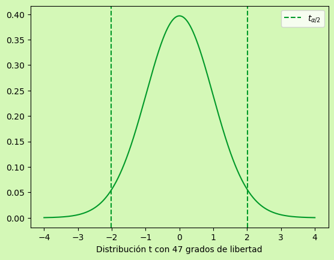

# Ejercicio 3

Considere la prueba de hipótesis siguiente.

$$H_0: \mu \geq 45 $$ $$ H_a: \mu < 45 $$

Se usa una muestra de 36. Identifique el valor-p y establezca su conclusión para cada uno de los siguientes resultados muestrales. Use $\alpha$ = 0.01 .

a) $ \bar{x} = 44$ y $s = 5.2 $

b) $ \bar{x} = 43 $ y $ s = 4.6 $

c) $ \bar{x} = 46 $ y $ s = 5.0 $

# Solucion

La prueba de hipótesis se realiza utilizando la fórmula del valor-p para una prueba de una cola (p-value):

$$ p = P(\bar{X} < \bar{x} \,|\, H_0 \, \text{es verdadera}) $$

**Donde:**

- $\bar{X}$ es la media muestral bajo la hipótesis nula,
- $\bar{x}$ es la media muestral observada,
- $n$ es el tamaño de la muestra, y
- $s$ es la desviación estándar muestral.

Si $p < \alpha$, se rechaza la hipótesis nula.

**a)**

Para $\bar{x} = 44$ y $s = 5.2$:

$$ p = P(\bar{X} < 44 \,|\, \mu \geq 45) $$

**b)**

Para $\bar{x} = 43$ y $s = 4.6$:

$$ p = P(\bar{X} < 43 \,|\, \mu \geq 45) $$

**c)**

Para $\bar{x} = 46$ y $s = 5.0$:

$$ p = P(\bar{X} < 46 \,|\, \mu \geq 45) $$

FIGURA 9.3

Valores críticos en la prueba de hipótesis"

```python
import numpy as np
import matplotlib.pyplot as plt
from scipy.stats import t

# Parámetros del problema
mu_0 = 45
alpha = 0.01
n = 36

# Valores críticos para la región de rechazo
critical_value = t.ppf(alpha, n-1)

# Datos para cada caso
sample_means = [44, 43, 46]
sample_std_devs = [5.2, 4.6, 5.0]

# Crear la gráfica
fig, ax = plt.subplots()

# Dibujar la distribución t bajo H0
x = np.linspace(mu_0 - 3 * (sample_std_devs[0] / np.sqrt(n)), mu_0 + 3 * (sample_std_devs[0] / np.sqrt(n)), 1000)
ax.plot(x, t.pdf(x, n-1), color='#009929', label=r'$H_0: \mu \geq 45$')

# Línea vertical en t crítico para alfa
ax.axvline(mu_0 + critical_value * (sample_std_devs[0] / np.sqrt(n)), color='#009929', linestyle='--', label=r'Región de Rechazo')

# Pintar el área de rechazo
x_fill = np.linspace(mu_0 + critical_value * (sample_std_devs[0] / np.sqrt(n)), mu_0 + 3 * (sample_std_devs[0] / np.sqrt(n)), 1000)
y_fill = t.pdf(x_fill, n-1)
ax.fill_between(x_fill, y_fill, color='#009929', alpha=0.3)

# Establecer el color de fondo
ax.set_facecolor('#d4f8b7')

# Pintar el fondo externo del gráfico
fig.patch.set_facecolor('#D4F8B7')

# Etiquetas y texto
ax.set_xlabel('Media Muestral ($\\bar{x}$)', fontsize=10)

# Ajustes del gráfico
ax.legend()
ax.grid(False)

# Mostrar la gráfica
plt.show()
```

[figure not shown]

## 9.5 Proporcion Poblacional

En esta sección se describe cómo realizar una prueba de hipótesis para la proporción poblacional p si mediante p0 se denota el valor hipotético para la proporción poblacional. Las tres formas de una prueba de hipótesis para la proporción poblacional son las siguientes:

| $H_{0}:p \geq p_0$ | $H_{0}:p \leq p_0$ | $H_{0}:p = p_0$ |
| --- | --- | --- |
| $H_{a}:p < p_0$ | $H_{a}:p > p_0$ | $H_{a}:p \neq p_0$ |

La primera forma es una prueba de cola inferior, la segunda es de cola superior y la tercera es de dos colas. Las pruebas de hipótesis para la proporción poblacional se basan en la diferencia entre la proporción muestral p y la proporción poblacional hipotética p0. Los métodos son semejantes a los usados para las pruebas de hipótesis de la media poblacional. La diferencia radica en que para calcular el estadístico de prueba se usa la proporción muestral y su error estándar. Para determinar si la hipótesis nula es rechazada, se utiliza el método del valor-p o el método del valor crítico.

# Ejemplo

Considere el caso del Coliseo de la UMSA del equipo de Voleibol. En los años anteriores, 20% de los jugadores del campo eran mujeres. Para aumentar la proporción del sector femenino, el directivo del equipo realizó una promoción especial diseñada para atraer a mujeres voleibolistas de la UMSA. Un mes después se realizada la promoción, el directivo del equipo solicitó un estudio estadístico para determinar si la proporción de jugadoras había aumentado. Como el objetivo es determinar si la proporción de jugadoras se incrementó, lo apropiado es una prueba de cola superior en la que $H_{a}:p > 0,20$  
Las hipotesis nula y alternativa para esta prueba son:

[output not shown]

Si $H_0$ se puede rechazar, los resultados de la prueba darán sustento estadístico a la conclusión de que la proporción de voleibolistas aumentó y que la promoción fue efectiva. El directivo del campo especificó que el nivel de significancia sera $α =0,05$ para realizar esta prueba de hipótesis  
El paso siguiente en el procedimiento de prueba de hipótesis es seleccionar una muestra y calcular el valor del estadístico de prueba adecuado.

Error estandar de $\bar{p}$:

\(\large \sigma_{\bar{p}}=\sqrt{\frac{p_0(1-p_0)}{n}}\)

En el capitulo 7 se dijo que si $np \geq 5$ y $n(1-p)$ la distribucion de muestreo de $\bar {p}$ puede aproximarse mediante una distribcion normal entonces aplicamos el estadistico:

\(\large z = \frac{\bar{p} - p_0}{\sigma_{\bar{p}}}\)

ESTADISTICO DE PRUEBA EN LAS PRUEBAS DE HIPOTESIS PARA LA PROPORCION POBLACIONAL:

\(\large z = \frac{\bar{p} - p_0}{\sqrt{\frac{p_0(1-p_0)}{n}}}\)

Teniendo la ecuacion para calcular el estadistico de prueba para la prueba de hipotesis del equipo de voleibol de la UMSA. Concideramos una muestra aletoria de 400jugadores en la que 100 son mujeres.

\(\large \bar {p} = \frac{100}{400}=0.25\)

Ya obteniendo la proporcion de la muestra, aplicamos la ecuacion del estadistico de prueba:

\(\large z = \frac{\bar{p} - p_0}{\sqrt{\frac{p_0(1-p_0)}{n}}}= \frac{0.25 - 0.20}{\sqrt{\frac{0.20(1-0.20)}{400}}}=\frac{0.05}{0.02}=2.50\)

Nuestra prueba de hipotesis para el equipo de voli es una cola superior, el valor-$p$ es la probabiidad de que $z$ sea mayor o igual que $z=2.50$;esto es, el area bajo la cuerva normal estandar para $z=2.50$.

```python
import numpy as np
import matplotlib.pyplot as plt
from scipy.stats import norm

# Generar datos de la distribución muestral
x = np.linspace(0 - 2.05 * 1, 0 + 2.05 * 1, 2000)
y = norm.pdf(x*4, 0, 2)

# Crear la gráfica
fig, ax = plt.subplots()
ax.plot(x, y, color='#009929')
# Establecer el color de fondo
ax.set_facecolor('#d4f8b7')
# Pintar el fondo externo del gráfico
fig.patch.set_facecolor('#D4F8B7')

# Agregar información sobre el error estándar


ax.text(0.60, 0.80, r'Área = 0.9938',transform=ax.transAxes, fontsize=10, color='#000')

ax.text(0.60, 0.10, r'Valor-p = P(z ≥ 2.50)=0.0062',transform=ax.transAxes, fontsize=10, color='#000')

ax.text(0.86, -0.11, r'2.5',transform=ax.transAxes, fontsize=12, color='#000')



ax.text(0.89, -0.04, r'|',transform=ax.transAxes, fontsize=12, color='#000')

ax.text(0.89, 0.01, r'|',transform=ax.transAxes, fontsize=12, color='#009929');ax.text(0.891, 0.01, r'|',transform=ax.transAxes, fontsize=12, color='#009929');ax.text(0.893, 0.01, r'|',transform=ax.transAxes, fontsize=12, color='#009929')
ax.text(0.895, 0.01, r'|',transform=ax.transAxes, fontsize=12, color='#009929');ax.text(0.897, 0.01, r'|',transform=ax.transAxes, fontsize=12, color='#009929');ax.text(0.899, 0.01, r'|',transform=ax.transAxes, fontsize=12, color='#009929')
ax.text(0.90, 0.01, r'|',transform=ax.transAxes, fontsize=12, color='#009929');ax.text(0.902, 0.01, r'|',transform=ax.transAxes, fontsize=12, color='#009929');ax.text(0.904, 0.01, r'|',transform=ax.transAxes, fontsize=12, color='#009929')
ax.text(0.906, 0.01, r'|',transform=ax.transAxes, fontsize=12, color='#009929');ax.text(0.908, 0.01, r'|',transform=ax.transAxes, fontsize=12, color='#009929');ax.text(0.910, 0.01, r'|',transform=ax.transAxes, fontsize=12, color='#009929')
ax.text(0.912, 0.01, r'|',transform=ax.transAxes, fontsize=12, color='#009929');ax.text(0.914, 0.01, r'|',transform=ax.transAxes, fontsize=12, color='#009929');ax.text(0.916, 0.01, r'|',transform=ax.transAxes, fontsize=12, color='#009929')
ax.text(0.918, 0.01, r'|',transform=ax.transAxes, fontsize=12, color='#009929');ax.text(0.920, 0.01, r'|',transform=ax.transAxes, fontsize=12, color='#009929');ax.text(0.922, 0.01, r'|',transform=ax.transAxes, fontsize=12, color='#009929')
ax.text(0.924, 0.01, r'|',transform=ax.transAxes, fontsize=12, color='#009929');ax.text(0.926, 0.01, r'|',transform=ax.transAxes, fontsize=12, color='#009929');ax.text(0.928, 0.01, r'|',transform=ax.transAxes, fontsize=12, color='#009929')
ax.text(0.930, 0.01, r'|',transform=ax.transAxes, fontsize=12, color='#009929');ax.text(0.932, 0.01, r'|',transform=ax.transAxes, fontsize=12, color='#009929');ax.text(0.934, 0.01, r'|',transform=ax.transAxes, fontsize=12, color='#009929')
ax.text(0.936, 0.01, r'|',transform=ax.transAxes, fontsize=12, color='#009929');ax.text(0.938, 0.01, r'|',transform=ax.transAxes, fontsize=12, color='#009929');ax.text(0.940, 0.01, r'|',transform=ax.transAxes, fontsize=12, color='#009929')
ax.text(0.942, 0.01, r'|',transform=ax.transAxes, fontsize=12, color='#009929');ax.text(0.944, 0.01, r'|',transform=ax.transAxes, fontsize=12, color='#009929');ax.text(0.946, 0.01, r'|',transform=ax.transAxes, fontsize=12, color='#009929')
ax.text(0.948, 0.01, r'|',transform=ax.transAxes, fontsize=12, color='#009929');ax.text(0.950, 0.01, r'|',transform=ax.transAxes, fontsize=12, color='#009929');ax.text(0.952, 0.01, r'|',transform=ax.transAxes, fontsize=12, color='#009929')
ax.text(0.954, 0.01, r'|',transform=ax.transAxes, fontsize=12, color='#009929');ax.text(0.956, 0.01, r'|',transform=ax.transAxes, fontsize=12, color='#009929');ax.text(0.958, 0.01, r'|',transform=ax.transAxes, fontsize=12, color='#009929')
ax.text(0.960, 0.01, r'|',transform=ax.transAxes, fontsize=12, color='#009929');ax.text(0.962, 0.01, r'|',transform=ax.transAxes, fontsize=12, color='#009929');ax.text(0.964, 0.01, r'|',transform=ax.transAxes, fontsize=12, color='#009929')
ax.text(0.966, 0.01, r'|',transform=ax.transAxes, fontsize=12, color='#009929');ax.text(0.968, 0.01, r'|',transform=ax.transAxes, fontsize=12, color='#009929');ax.text(0.970, 0.01, r'|',transform=ax.transAxes, fontsize=12, color='#009929')

ax.grid(False)
plt.show()
```

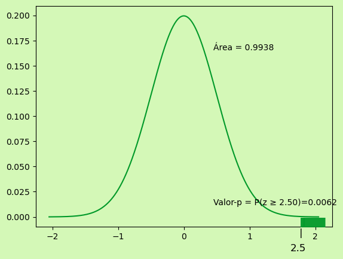

TABLA 9.4

Resumen de las pruebas de hipótesis para la proporcion poblacional

|  | Prueba de cola inferior | Prueba de cola superior | Prueba de dos colas |
| --- | --- | --- | --- |
| **Hipótesis** | $$H_0: p ≥ p_0$$ $$H_a: p < p_0$$ | $$H_0: p ≤ p_0$$ $$H_a: p > p_0$$ | $$H_0: p = p_0$$ $$H_a: p \ne p_0$$ |
| **Estadístico de prueba** | $$z = \frac{\bar{p} - p_0}{\sqrt{\frac{p_0(1-p_0)}{n}}}$$ | $$z = \frac{\bar{p} - p_0}{\sqrt{\frac{p_0(1-p_0)}{n}}}$$ | $$z = \frac{\bar{p} - p_0}{\sqrt{\frac{p_0(1-p_0)}{n}}}$$ |
| **Regla de rechazo: Método del valor-p** | Rechazar $H_0$ si el **valor-p** $≤ α$ | Rechazar $H_0$ si el **valor-p** $≤ α$ | Rechazar $H_0$ si el **valor-p** $≤ α$ |
| **Regla de rechazo: Método del valor crítico** | Rechazar $H_0$ si $z ≤ -z_α$ | Rechazar $H_0$ si $z ≥ z_α$ | Rechazar $H_0$ si $z ≤ -z_{α/2}$ o si $z ≥ z_{α/2}$ |

Para un valor-$p=0.0062$, la hipotesis nula sera rechazada para cualquier nivel de significancia mayor o igual que $0.0062$.

# Resumen

El procedimiento empleado en una prueba de hipótesis para la proporción poblacional es semejante al método usado en una prueba de hipótesis para la media poblacional. Aunque sólo se ilustró cómo realizar una prueba de hipótesis de cola superior para la proporción poblacional, en el caso de pruebas de cola inferior o de dos colas se recurre a procedimientos similares. En la tabla 9.4 se presenta una síntesis de las pruebas de hipótesis para la proporción poblacional. Se supone que $np \geq 5$ y $n(1-p)\geq 5$ , con lo cual se puede usar una distribución normal como aproximación a la distribución de muestreo de $\bar {p}$.

# Ejercicios

## Métodos

**1.** Considere la prueba de hipótesis siguiente.

$H_0: p = 0.20$  
$H_a: p \neq 0.20 $

En una muestra de 400, se encontro un proporcion muestral de $\bar {p}=0.175$  
a) **Calcule el valor del estadístico de prueba.**

b) **¿Cual es el valor-p.?**

c) **Con $\alpha = 0.05 $, ¿cuál es su conclusión?**

d) **¿Cuál es la regla de rechazo usando el valor crítico? ¿Qué concluye?**

# Solución

#### a) Estadístico de Prueba ((t)):

El estadístico de prueba (t) se calcula utilizando la fórmula:
$$ \large z = \frac{\bar{p} - p_0}{\sqrt{\frac{p_0(1-p_0)}{n}}} $$
Donde:

- $(\bar{p})$ es la proporcion muestral,
- $(p_0)$ es la proporcion poblacional,
- $(n)$ es el tamaño de la muestra.

En este caso: $$ \large z = \frac{0.175 - 0.20}{\sqrt{\frac{0.20(1-0.20)}{400}}} $$

Calculamos (z) y obtenemos el valor del estadístico de prueba.

#### b) Intervalo para el Valor-p:

Usaremos la tabla de distribución z para encontrar los valores críticos $(z_{\text{crítico}})$ y $(\alpha/2 = 0.025)$. Luego, calcularemos el intervalo para el valor-p.

#### c) Conclusión con $(\alpha = 0.05)$:

Si el valor-p es menor que $(\alpha)$, rechazamos la hipótesis nula $((H_0))$.

#### d) Regla de Rechazo usando el Valor Crítico:

Rechazamos $(H_0)$ si $(z > z_{\text{crítico}})$.

### Resultados:

a) **Estadístico de Prueba ((z)):**
$$ \large z = \frac{0.175 - 0.20}{\sqrt{\frac{0.20(1-0.20)}{400}}} $$

$$\large z = -1.25 $$

b) **Intervalo para el Valor-p:** Usando la tabla de distribución normal z, encontramos $(z_{\text{crítico}})$ para $( \alpha/2 = 0.025 )$.

c) Con $α = 0.05$

El valor$-p=2(0.1056)=0.2112$  
El valor$-p\neq (0.05);H_0$ no es rechazada

FIGURA 9.1

Valores críticos en la prueba de hipótesis"

```python
import numpy as np
import matplotlib.pyplot as plt
from scipy.stats import norm

# Generar datos de la distribución muestral
x = np.linspace(0 - 2.05 * 1, 0 + 2.05 * 1, 1000)
y = norm.pdf(x*4, 0, 2)

# Crear la gráfica
fig, ax = plt.subplots()
ax.plot(x, y, color='#009929')
# Establecer el color de fondo
ax.set_facecolor('#d4f8b7')
# Pintar el fondo externo del gráfico
fig.patch.set_facecolor('#D4F8B7')

# Agregar información sobre el error estándar


ax.text(0.06, -0.11, r'-1.36',transform=ax.transAxes, fontsize=12, color='#000')
ax.text(0.86, -0.11, r'1.36',transform=ax.transAxes, fontsize=12, color='#000')
ax.text(0.02, 0.15, r'P(z ≤ -1.25) = 0.1056', transform=ax.transAxes, fontsize=7.5, color='#000')
ax.text(0.76, 0.15, r'P(z ≥ 1.25) = 0.1056', transform=ax.transAxes, fontsize=7.5, color='#000')

ax.text(0.10, 0.01, r'|',transform=ax.transAxes, fontsize=12, color='#009929');ax.text(0.098, 0.01, r'|',transform=ax.transAxes, fontsize=12, color='#009929');ax.text(0.096, 0.01, r'|',transform=ax.transAxes, fontsize=12, color='#009929')
ax.text(0.094, 0.01, r'|',transform=ax.transAxes, fontsize=12, color='#009929');ax.text(0.092, 0.01, r'|',transform=ax.transAxes, fontsize=12, color='#009929');ax.text(0.090, 0.01, r'|',transform=ax.transAxes, fontsize=12, color='#009929')
ax.text(0.088, 0.01, r'|',transform=ax.transAxes, fontsize=12, color='#009929');ax.text(0.086, 0.01, r'|',transform=ax.transAxes, fontsize=12, color='#009929');ax.text(0.084, 0.01, r'|',transform=ax.transAxes, fontsize=12, color='#009929')
ax.text(0.082, 0.01, r'|',transform=ax.transAxes, fontsize=12, color='#009929');ax.text(0.080, 0.01, r'|',transform=ax.transAxes, fontsize=12, color='#009929');ax.text(0.078, 0.01, r'|',transform=ax.transAxes, fontsize=12, color='#009929')
ax.text(0.076, 0.01, r'|',transform=ax.transAxes, fontsize=12, color='#009929');ax.text(0.074, 0.01, r'|',transform=ax.transAxes, fontsize=12, color='#009929');ax.text(0.072, 0.01, r'|',transform=ax.transAxes, fontsize=12, color='#009929')
ax.text(0.070, 0.01, r'|',transform=ax.transAxes, fontsize=12, color='#009929');ax.text(0.068, 0.01, r'|',transform=ax.transAxes, fontsize=12, color='#009929');ax.text(0.066, 0.01, r'|',transform=ax.transAxes, fontsize=12, color='#009929')
ax.text(0.064, 0.01, r'|',transform=ax.transAxes, fontsize=12, color='#009929');ax.text(0.062, 0.01, r'|',transform=ax.transAxes, fontsize=12, color='#009929');ax.text(0.060, 0.01, r'|',transform=ax.transAxes, fontsize=12, color='#009929')
ax.text(0.058, 0.01, r'|',transform=ax.transAxes, fontsize=12, color='#009929');ax.text(0.056, 0.01, r'|',transform=ax.transAxes, fontsize=12, color='#009929');ax.text(0.054, 0.01, r'|',transform=ax.transAxes, fontsize=12, color='#009929')
ax.text(0.052, 0.01, r'|',transform=ax.transAxes, fontsize=12, color='#009929');ax.text(0.050, 0.01, r'|',transform=ax.transAxes, fontsize=12, color='#009929');ax.text(0.048, 0.01, r'|',transform=ax.transAxes, fontsize=12, color='#009929')
ax.text(0.046, 0.01, r'|',transform=ax.transAxes, fontsize=12, color='#009929');ax.text(0.044, 0.01, r'|',transform=ax.transAxes, fontsize=12, color='#009929');ax.text(0.042, 0.01, r'|',transform=ax.transAxes, fontsize=12, color='#009929')
ax.text(0.040, 0.01, r'|',transform=ax.transAxes, fontsize=12, color='#009929');ax.text(0.038, 0.01, r'|',transform=ax.transAxes, fontsize=12, color='#009929');ax.text(0.036, 0.01, r'|',transform=ax.transAxes, fontsize=12, color='#009929')
ax.text(0.034, 0.01, r'|',transform=ax.transAxes, fontsize=12, color='#009929');ax.text(0.032, 0.01, r'|',transform=ax.transAxes, fontsize=12, color='#009929');ax.text(0.030, 0.01, r'|',transform=ax.transAxes, fontsize=12, color='#009929')
ax.text(0.028, 0.01, r'|',transform=ax.transAxes, fontsize=12, color='#009929');ax.text(0.026, 0.01, r'|',transform=ax.transAxes, fontsize=12, color='#009929');ax.text(0.024, 0.01, r'|',transform=ax.transAxes, fontsize=12, color='#009929')
ax.text(0.022, 0.01, r'|',transform=ax.transAxes, fontsize=12, color='#009929');ax.text(0.020, 0.01, r'|',transform=ax.transAxes, fontsize=12, color='#009929');ax.text(0.028, 0.01, r'|',transform=ax.transAxes, fontsize=12, color='#009929')

ax.text(0.10, -0.04, r'|',transform=ax.transAxes, fontsize=12, color='#000')
ax.text(0.89, -0.04, r'|',transform=ax.transAxes, fontsize=12, color='#000')

ax.text(0.89, 0.01, r'|',transform=ax.transAxes, fontsize=12, color='#009929');ax.text(0.891, 0.01, r'|',transform=ax.transAxes, fontsize=12, color='#009929');ax.text(0.893, 0.01, r'|',transform=ax.transAxes, fontsize=12, color='#009929')
ax.text(0.895, 0.01, r'|',transform=ax.transAxes, fontsize=12, color='#009929');ax.text(0.897, 0.01, r'|',transform=ax.transAxes, fontsize=12, color='#009929');ax.text(0.899, 0.01, r'|',transform=ax.transAxes, fontsize=12, color='#009929')
ax.text(0.90, 0.01, r'|',transform=ax.transAxes, fontsize=12, color='#009929');ax.text(0.902, 0.01, r'|',transform=ax.transAxes, fontsize=12, color='#009929');ax.text(0.904, 0.01, r'|',transform=ax.transAxes, fontsize=12, color='#009929')
ax.text(0.906, 0.01, r'|',transform=ax.transAxes, fontsize=12, color='#009929');ax.text(0.908, 0.01, r'|',transform=ax.transAxes, fontsize=12, color='#009929');ax.text(0.910, 0.01, r'|',transform=ax.transAxes, fontsize=12, color='#009929')
ax.text(0.912, 0.01, r'|',transform=ax.transAxes, fontsize=12, color='#009929');ax.text(0.914, 0.01, r'|',transform=ax.transAxes, fontsize=12, color='#009929');ax.text(0.916, 0.01, r'|',transform=ax.transAxes, fontsize=12, color='#009929')
ax.text(0.918, 0.01, r'|',transform=ax.transAxes, fontsize=12, color='#009929');ax.text(0.920, 0.01, r'|',transform=ax.transAxes, fontsize=12, color='#009929');ax.text(0.922, 0.01, r'|',transform=ax.transAxes, fontsize=12, color='#009929')
ax.text(0.924, 0.01, r'|',transform=ax.transAxes, fontsize=12, color='#009929');ax.text(0.926, 0.01, r'|',transform=ax.transAxes, fontsize=12, color='#009929');ax.text(0.928, 0.01, r'|',transform=ax.transAxes, fontsize=12, color='#009929')
ax.text(0.930, 0.01, r'|',transform=ax.transAxes, fontsize=12, color='#009929');ax.text(0.932, 0.01, r'|',transform=ax.transAxes, fontsize=12, color='#009929');ax.text(0.934, 0.01, r'|',transform=ax.transAxes, fontsize=12, color='#009929')
ax.text(0.936, 0.01, r'|',transform=ax.transAxes, fontsize=12, color='#009929');ax.text(0.938, 0.01, r'|',transform=ax.transAxes, fontsize=12, color='#009929');ax.text(0.940, 0.01, r'|',transform=ax.transAxes, fontsize=12, color='#009929')
ax.text(0.942, 0.01, r'|',transform=ax.transAxes, fontsize=12, color='#009929');ax.text(0.944, 0.01, r'|',transform=ax.transAxes, fontsize=12, color='#009929');ax.text(0.946, 0.01, r'|',transform=ax.transAxes, fontsize=12, color='#009929')
ax.text(0.948, 0.01, r'|',transform=ax.transAxes, fontsize=12, color='#009929');ax.text(0.950, 0.01, r'|',transform=ax.transAxes, fontsize=12, color='#009929');ax.text(0.952, 0.01, r'|',transform=ax.transAxes, fontsize=12, color='#009929')
ax.text(0.954, 0.01, r'|',transform=ax.transAxes, fontsize=12, color='#009929');ax.text(0.956, 0.01, r'|',transform=ax.transAxes, fontsize=12, color='#009929');ax.text(0.958, 0.01, r'|',transform=ax.transAxes, fontsize=12, color='#009929')
ax.text(0.960, 0.01, r'|',transform=ax.transAxes, fontsize=12, color='#009929');ax.text(0.962, 0.01, r'|',transform=ax.transAxes, fontsize=12, color='#009929');ax.text(0.964, 0.01, r'|',transform=ax.transAxes, fontsize=12, color='#009929')
ax.text(0.966, 0.01, r'|',transform=ax.transAxes, fontsize=12, color='#009929');ax.text(0.968, 0.01, r'|',transform=ax.transAxes, fontsize=12, color='#009929');ax.text(0.970, 0.01, r'|',transform=ax.transAxes, fontsize=12, color='#009929')

ax.grid(False)
plt.show()
```

[figure not shown]

**2.** Considere la prueba de hipótesis siguiente.

$H_0: p \geq 0.75$  
$H_a: p < 0.75 $

En una muestra de 300 elementos. Calcule el valor-$p$ y estableza su conclusion para cada uno de los resultados muestrales siguiientes. Use $(\alpha = 0.05)$  
a) $\bar {p}=0.68$

b) $\bar {p}=0.72$

c) $\bar {p}=0.70$

d) $\bar {p}=0.77$

# Solución

Utilizando la fórmula:  
$ \large z = \frac{\bar{p} - p_0}{\sqrt{\frac{p_0(1-p_0)}{n}}} $  
Donde:

- $(\bar{p})$ es la proporcion muestral,
- $(p_0)$ es la proporcion poblacional,
- $(n)$ es el tamaño de la muestra.  
  Si valor-$p$ $es \leq \alpha$ rechazamos $H_0$

### Resultados:

**a) $\bar {p}=0.68$**

\(\large z = \frac{\bar{p} - p_0}{\sqrt{\frac{p_0(1-p_0)}{n}}}= \frac{0.68 - 0.75}{\sqrt{\frac{0.75(1-0.75)}{300}}}=-2.80\)  
El valor$-p=0.0026$  
El valor$-p\leq0.05; H_0$ es rechazada

b) $\bar {p}=0.72$

c) $\bar {p}=0.70$

\(\large z = \frac{\bar{p} - p_0}{\sqrt{\frac{p_0(1-p_0)}{n}}}= \frac{0.70 - 0.75}{\sqrt{\frac{0.75(1-0.75)}{300}}}=-2\)  
El valor$-p=0.0228$  
El valor$-p\leq0.05; H_0$ es rechazada

d) $\bar {p}=0.77$

FIGURA 9.2.1

Valores críticos en la prueba de hipótesis"

```python
import numpy as np
import matplotlib.pyplot as plt
from scipy.stats import norm

# Generar datos de la distribución muestral
x = np.linspace(0 - 2.05 * 1, 0 + 2.05 * 1, 2000)
y = norm.pdf(x*4, 0, 2)

# Crear la gráfica
fig, ax = plt.subplots()
ax.plot(x, y, color='#009929')
# Establecer el color de fondo
ax.set_facecolor('#d4f8b7')
# Pintar el fondo externo del gráfico
fig.patch.set_facecolor('#D4F8B7')

# Agregar información sobre el error estándar

ax.text(0.06, -0.11, r'-2.50',transform=ax.transAxes, fontsize=12, color='#000')
ax.text(0.60, 0.80, r'Área = 0.9974',transform=ax.transAxes, fontsize=10, color='#000')

ax.text(0.10, 0.10, r'Valor-p = P(z ≤ -2.80)=0.0026',transform=ax.transAxes, fontsize=10, color='#000')


ax.text(0.10, 0.01, r'|',transform=ax.transAxes, fontsize=12, color='#009929');ax.text(0.098, 0.01, r'|',transform=ax.transAxes, fontsize=12, color='#009929');ax.text(0.096, 0.01, r'|',transform=ax.transAxes, fontsize=12, color='#009929')
ax.text(0.094, 0.01, r'|',transform=ax.transAxes, fontsize=12, color='#009929');ax.text(0.092, 0.01, r'|',transform=ax.transAxes, fontsize=12, color='#009929');ax.text(0.090, 0.01, r'|',transform=ax.transAxes, fontsize=12, color='#009929')
ax.text(0.088, 0.01, r'|',transform=ax.transAxes, fontsize=12, color='#009929');ax.text(0.086, 0.01, r'|',transform=ax.transAxes, fontsize=12, color='#009929');ax.text(0.084, 0.01, r'|',transform=ax.transAxes, fontsize=12, color='#009929')
ax.text(0.082, 0.01, r'|',transform=ax.transAxes, fontsize=12, color='#009929');ax.text(0.080, 0.01, r'|',transform=ax.transAxes, fontsize=12, color='#009929');ax.text(0.078, 0.01, r'|',transform=ax.transAxes, fontsize=12, color='#009929')
ax.text(0.076, 0.01, r'|',transform=ax.transAxes, fontsize=12, color='#009929');ax.text(0.074, 0.01, r'|',transform=ax.transAxes, fontsize=12, color='#009929');ax.text(0.072, 0.01, r'|',transform=ax.transAxes, fontsize=12, color='#009929')
ax.text(0.070, 0.01, r'|',transform=ax.transAxes, fontsize=12, color='#009929');ax.text(0.068, 0.01, r'|',transform=ax.transAxes, fontsize=12, color='#009929');ax.text(0.066, 0.01, r'|',transform=ax.transAxes, fontsize=12, color='#009929')
ax.text(0.064, 0.01, r'|',transform=ax.transAxes, fontsize=12, color='#009929');ax.text(0.062, 0.01, r'|',transform=ax.transAxes, fontsize=12, color='#009929');ax.text(0.060, 0.01, r'|',transform=ax.transAxes, fontsize=12, color='#009929')
ax.text(0.058, 0.01, r'|',transform=ax.transAxes, fontsize=12, color='#009929');ax.text(0.056, 0.01, r'|',transform=ax.transAxes, fontsize=12, color='#009929');ax.text(0.054, 0.01, r'|',transform=ax.transAxes, fontsize=12, color='#009929')
ax.text(0.052, 0.01, r'|',transform=ax.transAxes, fontsize=12, color='#009929');ax.text(0.050, 0.01, r'|',transform=ax.transAxes, fontsize=12, color='#009929');ax.text(0.048, 0.01, r'|',transform=ax.transAxes, fontsize=12, color='#009929')
ax.text(0.046, 0.01, r'|',transform=ax.transAxes, fontsize=12, color='#009929');ax.text(0.044, 0.01, r'|',transform=ax.transAxes, fontsize=12, color='#009929');ax.text(0.042, 0.01, r'|',transform=ax.transAxes, fontsize=12, color='#009929')
ax.text(0.040, 0.01, r'|',transform=ax.transAxes, fontsize=12, color='#009929');ax.text(0.038, 0.01, r'|',transform=ax.transAxes, fontsize=12, color='#009929');ax.text(0.036, 0.01, r'|',transform=ax.transAxes, fontsize=12, color='#009929')
ax.text(0.034, 0.01, r'|',transform=ax.transAxes, fontsize=12, color='#009929');ax.text(0.032, 0.01, r'|',transform=ax.transAxes, fontsize=12, color='#009929');ax.text(0.030, 0.01, r'|',transform=ax.transAxes, fontsize=12, color='#009929')
ax.text(0.028, 0.01, r'|',transform=ax.transAxes, fontsize=12, color='#009929');ax.text(0.026, 0.01, r'|',transform=ax.transAxes, fontsize=12, color='#009929');ax.text(0.024, 0.01, r'|',transform=ax.transAxes, fontsize=12, color='#009929')
ax.text(0.022, 0.01, r'|',transform=ax.transAxes, fontsize=12, color='#009929');ax.text(0.020, 0.01, r'|',transform=ax.transAxes, fontsize=12, color='#009929');ax.text(0.028, 0.01, r'|',transform=ax.transAxes, fontsize=12, color='#009929')


ax.text(0.89, -0.04, r'|',transform=ax.transAxes, fontsize=12, color='#000')



ax.grid(False)
plt.show()
```

[figure not shown]

FIGURA 9.2.3

Valores críticos en la prueba de hipótesis"

```python
import numpy as np
import matplotlib.pyplot as plt
from scipy.stats import norm

# Generar datos de la distribución muestral
x = np.linspace(0 - 2.05 * 1, 0 + 2.05 * 1, 2000)
y = norm.pdf(x*4, 0, 2)

# Crear la gráfica
fig, ax = plt.subplots()
ax.plot(x, y, color='#009929')
# Establecer el color de fondo
ax.set_facecolor('#d4f8b7')
# Pintar el fondo externo del gráfico
fig.patch.set_facecolor('#D4F8B7')

# Agregar información sobre el error estándar

ax.text(0.06, -0.11, r'-1.20',transform=ax.transAxes, fontsize=12, color='#000')
ax.text(0.60, 0.80, r'Área = 0.8849',transform=ax.transAxes, fontsize=10, color='#000')

ax.text(0.10, 0.10, r'Valor-p = P(z ≤ -1.20)=0.1151',transform=ax.transAxes, fontsize=10, color='#000')


ax.text(0.10, 0.01, r'|',transform=ax.transAxes, fontsize=12, color='#009929');ax.text(0.098, 0.01, r'|',transform=ax.transAxes, fontsize=12, color='#009929');ax.text(0.096, 0.01, r'|',transform=ax.transAxes, fontsize=12, color='#009929')
ax.text(0.094, 0.01, r'|',transform=ax.transAxes, fontsize=12, color='#009929');ax.text(0.092, 0.01, r'|',transform=ax.transAxes, fontsize=12, color='#009929');ax.text(0.090, 0.01, r'|',transform=ax.transAxes, fontsize=12, color='#009929')
ax.text(0.088, 0.01, r'|',transform=ax.transAxes, fontsize=12, color='#009929');ax.text(0.086, 0.01, r'|',transform=ax.transAxes, fontsize=12, color='#009929');ax.text(0.084, 0.01, r'|',transform=ax.transAxes, fontsize=12, color='#009929')
ax.text(0.082, 0.01, r'|',transform=ax.transAxes, fontsize=12, color='#009929');ax.text(0.080, 0.01, r'|',transform=ax.transAxes, fontsize=12, color='#009929');ax.text(0.078, 0.01, r'|',transform=ax.transAxes, fontsize=12, color='#009929')
ax.text(0.076, 0.01, r'|',transform=ax.transAxes, fontsize=12, color='#009929');ax.text(0.074, 0.01, r'|',transform=ax.transAxes, fontsize=12, color='#009929');ax.text(0.072, 0.01, r'|',transform=ax.transAxes, fontsize=12, color='#009929')
ax.text(0.070, 0.01, r'|',transform=ax.transAxes, fontsize=12, color='#009929');ax.text(0.068, 0.01, r'|',transform=ax.transAxes, fontsize=12, color='#009929');ax.text(0.066, 0.01, r'|',transform=ax.transAxes, fontsize=12, color='#009929')
ax.text(0.064, 0.01, r'|',transform=ax.transAxes, fontsize=12, color='#009929');ax.text(0.062, 0.01, r'|',transform=ax.transAxes, fontsize=12, color='#009929');ax.text(0.060, 0.01, r'|',transform=ax.transAxes, fontsize=12, color='#009929')
ax.text(0.058, 0.01, r'|',transform=ax.transAxes, fontsize=12, color='#009929');ax.text(0.056, 0.01, r'|',transform=ax.transAxes, fontsize=12, color='#009929');ax.text(0.054, 0.01, r'|',transform=ax.transAxes, fontsize=12, color='#009929')
ax.text(0.052, 0.01, r'|',transform=ax.transAxes, fontsize=12, color='#009929');ax.text(0.050, 0.01, r'|',transform=ax.transAxes, fontsize=12, color='#009929');ax.text(0.048, 0.01, r'|',transform=ax.transAxes, fontsize=12, color='#009929')
ax.text(0.046, 0.01, r'|',transform=ax.transAxes, fontsize=12, color='#009929');ax.text(0.044, 0.01, r'|',transform=ax.transAxes, fontsize=12, color='#009929');ax.text(0.042, 0.01, r'|',transform=ax.transAxes, fontsize=12, color='#009929')
ax.text(0.040, 0.01, r'|',transform=ax.transAxes, fontsize=12, color='#009929');ax.text(0.038, 0.01, r'|',transform=ax.transAxes, fontsize=12, color='#009929');ax.text(0.036, 0.01, r'|',transform=ax.transAxes, fontsize=12, color='#009929')
ax.text(0.034, 0.01, r'|',transform=ax.transAxes, fontsize=12, color='#009929');ax.text(0.032, 0.01, r'|',transform=ax.transAxes, fontsize=12, color='#009929');ax.text(0.030, 0.01, r'|',transform=ax.transAxes, fontsize=12, color='#009929')
ax.text(0.028, 0.01, r'|',transform=ax.transAxes, fontsize=12, color='#009929');ax.text(0.026, 0.01, r'|',transform=ax.transAxes, fontsize=12, color='#009929');ax.text(0.024, 0.01, r'|',transform=ax.transAxes, fontsize=12, color='#009929')
ax.text(0.022, 0.01, r'|',transform=ax.transAxes, fontsize=12, color='#009929');ax.text(0.020, 0.01, r'|',transform=ax.transAxes, fontsize=12, color='#009929');ax.text(0.028, 0.01, r'|',transform=ax.transAxes, fontsize=12, color='#009929')


ax.text(0.89, -0.04, r'|',transform=ax.transAxes, fontsize=12, color='#000')



ax.grid(False)
plt.show()
```

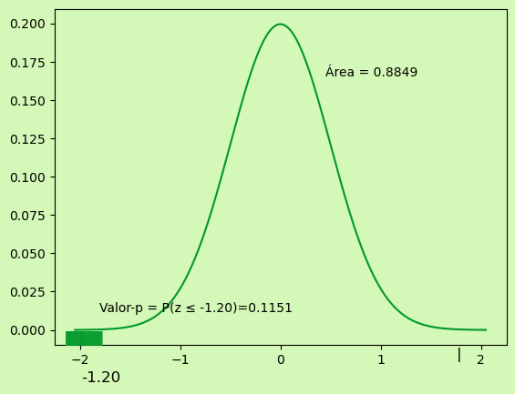

FIGURA 9.2.3

Valores críticos en la prueba de hipótesis"

```python
import numpy as np
import matplotlib.pyplot as plt
from scipy.stats import norm

# Generar datos de la distribución muestral
x = np.linspace(0 - 2.05 * 1, 0 + 2.05 * 1, 2000)
y = norm.pdf(x*4, 0, 2)

# Crear la gráfica
fig, ax = plt.subplots()
ax.plot(x, y, color='#009929')
# Establecer el color de fondo
ax.set_facecolor('#d4f8b7')
# Pintar el fondo externo del gráfico
fig.patch.set_facecolor('#D4F8B7')

# Agregar información sobre el error estándar

ax.text(0.06, -0.11, r'-2.00',transform=ax.transAxes, fontsize=12, color='#000')
ax.text(0.60, 0.80, r'Área = 0.9778',transform=ax.transAxes, fontsize=10, color='#000')

ax.text(0.10, 0.10, r'Valor-p = P(z ≤ -2.00)=0.0228',transform=ax.transAxes, fontsize=10, color='#000')


ax.text(0.10, 0.01, r'|',transform=ax.transAxes, fontsize=12, color='#009929');ax.text(0.098, 0.01, r'|',transform=ax.transAxes, fontsize=12, color='#009929');ax.text(0.096, 0.01, r'|',transform=ax.transAxes, fontsize=12, color='#009929')
ax.text(0.094, 0.01, r'|',transform=ax.transAxes, fontsize=12, color='#009929');ax.text(0.092, 0.01, r'|',transform=ax.transAxes, fontsize=12, color='#009929');ax.text(0.090, 0.01, r'|',transform=ax.transAxes, fontsize=12, color='#009929')
ax.text(0.088, 0.01, r'|',transform=ax.transAxes, fontsize=12, color='#009929');ax.text(0.086, 0.01, r'|',transform=ax.transAxes, fontsize=12, color='#009929');ax.text(0.084, 0.01, r'|',transform=ax.transAxes, fontsize=12, color='#009929')
ax.text(0.082, 0.01, r'|',transform=ax.transAxes, fontsize=12, color='#009929');ax.text(0.080, 0.01, r'|',transform=ax.transAxes, fontsize=12, color='#009929');ax.text(0.078, 0.01, r'|',transform=ax.transAxes, fontsize=12, color='#009929')
ax.text(0.076, 0.01, r'|',transform=ax.transAxes, fontsize=12, color='#009929');ax.text(0.074, 0.01, r'|',transform=ax.transAxes, fontsize=12, color='#009929');ax.text(0.072, 0.01, r'|',transform=ax.transAxes, fontsize=12, color='#009929')
ax.text(0.070, 0.01, r'|',transform=ax.transAxes, fontsize=12, color='#009929');ax.text(0.068, 0.01, r'|',transform=ax.transAxes, fontsize=12, color='#009929');ax.text(0.066, 0.01, r'|',transform=ax.transAxes, fontsize=12, color='#009929')
ax.text(0.064, 0.01, r'|',transform=ax.transAxes, fontsize=12, color='#009929');ax.text(0.062, 0.01, r'|',transform=ax.transAxes, fontsize=12, color='#009929');ax.text(0.060, 0.01, r'|',transform=ax.transAxes, fontsize=12, color='#009929')
ax.text(0.058, 0.01, r'|',transform=ax.transAxes, fontsize=12, color='#009929');ax.text(0.056, 0.01, r'|',transform=ax.transAxes, fontsize=12, color='#009929');ax.text(0.054, 0.01, r'|',transform=ax.transAxes, fontsize=12, color='#009929')
ax.text(0.052, 0.01, r'|',transform=ax.transAxes, fontsize=12, color='#009929');ax.text(0.050, 0.01, r'|',transform=ax.transAxes, fontsize=12, color='#009929');ax.text(0.048, 0.01, r'|',transform=ax.transAxes, fontsize=12, color='#009929')
ax.text(0.046, 0.01, r'|',transform=ax.transAxes, fontsize=12, color='#009929');ax.text(0.044, 0.01, r'|',transform=ax.transAxes, fontsize=12, color='#009929');ax.text(0.042, 0.01, r'|',transform=ax.transAxes, fontsize=12, color='#009929')
ax.text(0.040, 0.01, r'|',transform=ax.transAxes, fontsize=12, color='#009929');ax.text(0.038, 0.01, r'|',transform=ax.transAxes, fontsize=12, color='#009929');ax.text(0.036, 0.01, r'|',transform=ax.transAxes, fontsize=12, color='#009929')
ax.text(0.034, 0.01, r'|',transform=ax.transAxes, fontsize=12, color='#009929');ax.text(0.032, 0.01, r'|',transform=ax.transAxes, fontsize=12, color='#009929');ax.text(0.030, 0.01, r'|',transform=ax.transAxes, fontsize=12, color='#009929')
ax.text(0.028, 0.01, r'|',transform=ax.transAxes, fontsize=12, color='#009929');ax.text(0.026, 0.01, r'|',transform=ax.transAxes, fontsize=12, color='#009929');ax.text(0.024, 0.01, r'|',transform=ax.transAxes, fontsize=12, color='#009929')
ax.text(0.022, 0.01, r'|',transform=ax.transAxes, fontsize=12, color='#009929');ax.text(0.020, 0.01, r'|',transform=ax.transAxes, fontsize=12, color='#009929');ax.text(0.028, 0.01, r'|',transform=ax.transAxes, fontsize=12, color='#009929')


ax.text(0.89, -0.04, r'|',transform=ax.transAxes, fontsize=12, color='#000')



ax.grid(False)
plt.show()
```

[figure not shown]

FIGURA 9.2.4

Valores críticos en la prueba de hipótesis"

```python
import numpy as np
import matplotlib.pyplot as plt
from scipy.stats import norm

# Generar datos de la distribución muestral
x = np.linspace(0 - 2.05 * 1, 0 + 2.05 * 1, 2000)
y = norm.pdf(x*4, 0, 2)

# Crear la gráfica
fig, ax = plt.subplots()
ax.plot(x, y, color='#009929')
# Establecer el color de fondo
ax.set_facecolor('#d4f8b7')
# Pintar el fondo externo del gráfico
fig.patch.set_facecolor('#D4F8B7')

# Agregar información sobre el error estándar

ax.text(0.06, -0.11, r'0.80',transform=ax.transAxes, fontsize=12, color='#000')
ax.text(0.60, 0.80, r'Área = 0.2119',transform=ax.transAxes, fontsize=10, color='#000')

ax.text(0.10, 0.10, r'Valor-p = P(z ≤ 0.80)=0.7881',transform=ax.transAxes, fontsize=10, color='#000')


ax.text(0.10, 0.01, r'|',transform=ax.transAxes, fontsize=12, color='#009929');ax.text(0.098, 0.01, r'|',transform=ax.transAxes, fontsize=12, color='#009929');ax.text(0.096, 0.01, r'|',transform=ax.transAxes, fontsize=12, color='#009929')
ax.text(0.094, 0.01, r'|',transform=ax.transAxes, fontsize=12, color='#009929');ax.text(0.092, 0.01, r'|',transform=ax.transAxes, fontsize=12, color='#009929');ax.text(0.090, 0.01, r'|',transform=ax.transAxes, fontsize=12, color='#009929')
ax.text(0.088, 0.01, r'|',transform=ax.transAxes, fontsize=12, color='#009929');ax.text(0.086, 0.01, r'|',transform=ax.transAxes, fontsize=12, color='#009929');ax.text(0.084, 0.01, r'|',transform=ax.transAxes, fontsize=12, color='#009929')
ax.text(0.082, 0.01, r'|',transform=ax.transAxes, fontsize=12, color='#009929');ax.text(0.080, 0.01, r'|',transform=ax.transAxes, fontsize=12, color='#009929');ax.text(0.078, 0.01, r'|',transform=ax.transAxes, fontsize=12, color='#009929')
ax.text(0.076, 0.01, r'|',transform=ax.transAxes, fontsize=12, color='#009929');ax.text(0.074, 0.01, r'|',transform=ax.transAxes, fontsize=12, color='#009929');ax.text(0.072, 0.01, r'|',transform=ax.transAxes, fontsize=12, color='#009929')
ax.text(0.070, 0.01, r'|',transform=ax.transAxes, fontsize=12, color='#009929');ax.text(0.068, 0.01, r'|',transform=ax.transAxes, fontsize=12, color='#009929');ax.text(0.066, 0.01, r'|',transform=ax.transAxes, fontsize=12, color='#009929')
ax.text(0.064, 0.01, r'|',transform=ax.transAxes, fontsize=12, color='#009929');ax.text(0.062, 0.01, r'|',transform=ax.transAxes, fontsize=12, color='#009929');ax.text(0.060, 0.01, r'|',transform=ax.transAxes, fontsize=12, color='#009929')
ax.text(0.058, 0.01, r'|',transform=ax.transAxes, fontsize=12, color='#009929');ax.text(0.056, 0.01, r'|',transform=ax.transAxes, fontsize=12, color='#009929');ax.text(0.054, 0.01, r'|',transform=ax.transAxes, fontsize=12, color='#009929')
ax.text(0.052, 0.01, r'|',transform=ax.transAxes, fontsize=12, color='#009929');ax.text(0.050, 0.01, r'|',transform=ax.transAxes, fontsize=12, color='#009929');ax.text(0.048, 0.01, r'|',transform=ax.transAxes, fontsize=12, color='#009929')
ax.text(0.046, 0.01, r'|',transform=ax.transAxes, fontsize=12, color='#009929');ax.text(0.044, 0.01, r'|',transform=ax.transAxes, fontsize=12, color='#009929');ax.text(0.042, 0.01, r'|',transform=ax.transAxes, fontsize=12, color='#009929')
ax.text(0.040, 0.01, r'|',transform=ax.transAxes, fontsize=12, color='#009929');ax.text(0.038, 0.01, r'|',transform=ax.transAxes, fontsize=12, color='#009929');ax.text(0.036, 0.01, r'|',transform=ax.transAxes, fontsize=12, color='#009929')
ax.text(0.034, 0.01, r'|',transform=ax.transAxes, fontsize=12, color='#009929');ax.text(0.032, 0.01, r'|',transform=ax.transAxes, fontsize=12, color='#009929');ax.text(0.030, 0.01, r'|',transform=ax.transAxes, fontsize=12, color='#009929')
ax.text(0.028, 0.01, r'|',transform=ax.transAxes, fontsize=12, color='#009929');ax.text(0.026, 0.01, r'|',transform=ax.transAxes, fontsize=12, color='#009929');ax.text(0.024, 0.01, r'|',transform=ax.transAxes, fontsize=12, color='#009929')
ax.text(0.022, 0.01, r'|',transform=ax.transAxes, fontsize=12, color='#009929');ax.text(0.020, 0.01, r'|',transform=ax.transAxes, fontsize=12, color='#009929');ax.text(0.028, 0.01, r'|',transform=ax.transAxes, fontsize=12, color='#009929')


ax.text(0.89, -0.04, r'|',transform=ax.transAxes, fontsize=12, color='#000')



ax.grid(False)
plt.show()
```

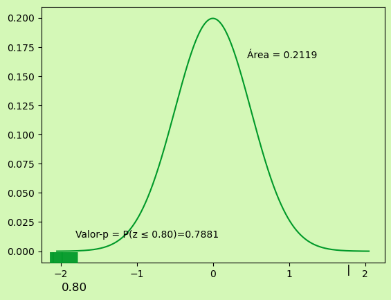

3. Un estudio realizado por La Alcaldia de La Paz indica que 64% de los clientes de los supermercados piensa que las marcas de esos establecimientos son tan buenas como las marcas nacionales. Para investigar si estos resultados aplican a sus propios productos, un fabricante de salsa de tomate de una marca nacional preguntó a los integrantes de una muestra si consideraban las salsas de tomate de marca propia de los supermercados tan buenas como la de marca nacional.  
$a)$ Formule las hipótesis para determinar si el porcentaje de clientes de los supermercados que considera las salsas de tomate de marca propia de estos establecimientos tan buenas como la de marca nacional difiere de $64$%.  
$b)$ Si en una muestra de $100$ clientes, $52$ opinan que las marcas de los supermercados son tan buenas como las nacionales, ¿cuál es el valor-$p$?  
$c)$ Con α = 0.05, ¿cuál es la conclusión?  
$d)$ ¿Le dará gusto esta conclusión al fabricante de la marca nacional de salsa de tomate? Explique.

# Solución

Utilizando la fórmula:  
$ \large z = \frac{\bar{p} - p_0}{\sqrt{\frac{p_0(1-p_0)}{n}}} $  
Donde:

- $(\bar{p})$ es la proporcion muestral,
- $(p_0)$ es la proporcion poblacional,
- $(n)$ es el tamaño de la muestra.  
  Si valor-$p$ $es \leq \alpha$ rechazamos $H_0$

### Resultados:

a) con el $64$%

$H_0: p = 0.64$  
$H_a: p \neq 0.64 $

\(\large z = \frac{\bar{p} - p_0}{\sqrt{\frac{p_0(1-p_0)}{n}}}= \frac{0.52 - 0.64}{\sqrt{\frac{0.64(1-0.64)}{100}}}=-2.50\)  
El valor$-p=2(0.0062)$

FIGURA 9.3

Valores críticos en la prueba de hipótesis"

```python
import numpy as np
import matplotlib.pyplot as plt
from scipy.stats import norm

# Generar datos de la distribución muestral
x = np.linspace(0 - 2.05 * 1, 0 + 2.05 * 1, 1000)
y = norm.pdf(x*4, 0, 2)

# Crear la gráfica
fig, ax = plt.subplots()
ax.plot(x, y, color='#009929')
# Establecer el color de fondo
ax.set_facecolor('#d4f8b7')
# Pintar el fondo externo del gráfico
fig.patch.set_facecolor('#D4F8B7')

# Agregar información sobre el error estándar


ax.text(0.06, -0.11, r'-2.50',transform=ax.transAxes, fontsize=12, color='#000')
ax.text(0.86, -0.11, r'2.50',transform=ax.transAxes, fontsize=12, color='#000')
ax.text(0.02, 0.15, r'P(z ≤ -2.50) = 0.0062', transform=ax.transAxes, fontsize=7.5, color='#000')
ax.text(0.76, 0.15, r'P(z ≥ 2.96) = 0.0062', transform=ax.transAxes, fontsize=7.5, color='#000')

ax.text(0.10, 0.01, r'|',transform=ax.transAxes, fontsize=12, color='#009929');ax.text(0.098, 0.01, r'|',transform=ax.transAxes, fontsize=12, color='#009929');ax.text(0.096, 0.01, r'|',transform=ax.transAxes, fontsize=12, color='#009929')
ax.text(0.094, 0.01, r'|',transform=ax.transAxes, fontsize=12, color='#009929');ax.text(0.092, 0.01, r'|',transform=ax.transAxes, fontsize=12, color='#009929');ax.text(0.090, 0.01, r'|',transform=ax.transAxes, fontsize=12, color='#009929')
ax.text(0.088, 0.01, r'|',transform=ax.transAxes, fontsize=12, color='#009929');ax.text(0.086, 0.01, r'|',transform=ax.transAxes, fontsize=12, color='#009929');ax.text(0.084, 0.01, r'|',transform=ax.transAxes, fontsize=12, color='#009929')
ax.text(0.082, 0.01, r'|',transform=ax.transAxes, fontsize=12, color='#009929');ax.text(0.080, 0.01, r'|',transform=ax.transAxes, fontsize=12, color='#009929');ax.text(0.078, 0.01, r'|',transform=ax.transAxes, fontsize=12, color='#009929')
ax.text(0.076, 0.01, r'|',transform=ax.transAxes, fontsize=12, color='#009929');ax.text(0.074, 0.01, r'|',transform=ax.transAxes, fontsize=12, color='#009929');ax.text(0.072, 0.01, r'|',transform=ax.transAxes, fontsize=12, color='#009929')
ax.text(0.070, 0.01, r'|',transform=ax.transAxes, fontsize=12, color='#009929');ax.text(0.068, 0.01, r'|',transform=ax.transAxes, fontsize=12, color='#009929');ax.text(0.066, 0.01, r'|',transform=ax.transAxes, fontsize=12, color='#009929')
ax.text(0.064, 0.01, r'|',transform=ax.transAxes, fontsize=12, color='#009929');ax.text(0.062, 0.01, r'|',transform=ax.transAxes, fontsize=12, color='#009929');ax.text(0.060, 0.01, r'|',transform=ax.transAxes, fontsize=12, color='#009929')
ax.text(0.058, 0.01, r'|',transform=ax.transAxes, fontsize=12, color='#009929');ax.text(0.056, 0.01, r'|',transform=ax.transAxes, fontsize=12, color='#009929');ax.text(0.054, 0.01, r'|',transform=ax.transAxes, fontsize=12, color='#009929')
ax.text(0.052, 0.01, r'|',transform=ax.transAxes, fontsize=12, color='#009929');ax.text(0.050, 0.01, r'|',transform=ax.transAxes, fontsize=12, color='#009929');ax.text(0.048, 0.01, r'|',transform=ax.transAxes, fontsize=12, color='#009929')
ax.text(0.046, 0.01, r'|',transform=ax.transAxes, fontsize=12, color='#009929');ax.text(0.044, 0.01, r'|',transform=ax.transAxes, fontsize=12, color='#009929');ax.text(0.042, 0.01, r'|',transform=ax.transAxes, fontsize=12, color='#009929')
ax.text(0.040, 0.01, r'|',transform=ax.transAxes, fontsize=12, color='#009929');ax.text(0.038, 0.01, r'|',transform=ax.transAxes, fontsize=12, color='#009929');ax.text(0.036, 0.01, r'|',transform=ax.transAxes, fontsize=12, color='#009929')
ax.text(0.034, 0.01, r'|',transform=ax.transAxes, fontsize=12, color='#009929');ax.text(0.032, 0.01, r'|',transform=ax.transAxes, fontsize=12, color='#009929');ax.text(0.030, 0.01, r'|',transform=ax.transAxes, fontsize=12, color='#009929')
ax.text(0.028, 0.01, r'|',transform=ax.transAxes, fontsize=12, color='#009929');ax.text(0.026, 0.01, r'|',transform=ax.transAxes, fontsize=12, color='#009929');ax.text(0.024, 0.01, r'|',transform=ax.transAxes, fontsize=12, color='#009929')
ax.text(0.022, 0.01, r'|',transform=ax.transAxes, fontsize=12, color='#009929');ax.text(0.020, 0.01, r'|',transform=ax.transAxes, fontsize=12, color='#009929');ax.text(0.028, 0.01, r'|',transform=ax.transAxes, fontsize=12, color='#009929')

ax.text(0.10, -0.04, r'|',transform=ax.transAxes, fontsize=12, color='#000')
ax.text(0.89, -0.04, r'|',transform=ax.transAxes, fontsize=12, color='#000')

ax.text(0.89, 0.01, r'|',transform=ax.transAxes, fontsize=12, color='#009929');ax.text(0.891, 0.01, r'|',transform=ax.transAxes, fontsize=12, color='#009929');ax.text(0.893, 0.01, r'|',transform=ax.transAxes, fontsize=12, color='#009929')
ax.text(0.895, 0.01, r'|',transform=ax.transAxes, fontsize=12, color='#009929');ax.text(0.897, 0.01, r'|',transform=ax.transAxes, fontsize=12, color='#009929');ax.text(0.899, 0.01, r'|',transform=ax.transAxes, fontsize=12, color='#009929')
ax.text(0.90, 0.01, r'|',transform=ax.transAxes, fontsize=12, color='#009929');ax.text(0.902, 0.01, r'|',transform=ax.transAxes, fontsize=12, color='#009929');ax.text(0.904, 0.01, r'|',transform=ax.transAxes, fontsize=12, color='#009929')
ax.text(0.906, 0.01, r'|',transform=ax.transAxes, fontsize=12, color='#009929');ax.text(0.908, 0.01, r'|',transform=ax.transAxes, fontsize=12, color='#009929');ax.text(0.910, 0.01, r'|',transform=ax.transAxes, fontsize=12, color='#009929')
ax.text(0.912, 0.01, r'|',transform=ax.transAxes, fontsize=12, color='#009929');ax.text(0.914, 0.01, r'|',transform=ax.transAxes, fontsize=12, color='#009929');ax.text(0.916, 0.01, r'|',transform=ax.transAxes, fontsize=12, color='#009929')
ax.text(0.918, 0.01, r'|',transform=ax.transAxes, fontsize=12, color='#009929');ax.text(0.920, 0.01, r'|',transform=ax.transAxes, fontsize=12, color='#009929');ax.text(0.922, 0.01, r'|',transform=ax.transAxes, fontsize=12, color='#009929')
ax.text(0.924, 0.01, r'|',transform=ax.transAxes, fontsize=12, color='#009929');ax.text(0.926, 0.01, r'|',transform=ax.transAxes, fontsize=12, color='#009929');ax.text(0.928, 0.01, r'|',transform=ax.transAxes, fontsize=12, color='#009929')
ax.text(0.930, 0.01, r'|',transform=ax.transAxes, fontsize=12, color='#009929');ax.text(0.932, 0.01, r'|',transform=ax.transAxes, fontsize=12, color='#009929');ax.text(0.934, 0.01, r'|',transform=ax.transAxes, fontsize=12, color='#009929')
ax.text(0.936, 0.01, r'|',transform=ax.transAxes, fontsize=12, color='#009929');ax.text(0.938, 0.01, r'|',transform=ax.transAxes, fontsize=12, color='#009929');ax.text(0.940, 0.01, r'|',transform=ax.transAxes, fontsize=12, color='#009929')
ax.text(0.942, 0.01, r'|',transform=ax.transAxes, fontsize=12, color='#009929');ax.text(0.944, 0.01, r'|',transform=ax.transAxes, fontsize=12, color='#009929');ax.text(0.946, 0.01, r'|',transform=ax.transAxes, fontsize=12, color='#009929')
ax.text(0.948, 0.01, r'|',transform=ax.transAxes, fontsize=12, color='#009929');ax.text(0.950, 0.01, r'|',transform=ax.transAxes, fontsize=12, color='#009929');ax.text(0.952, 0.01, r'|',transform=ax.transAxes, fontsize=12, color='#009929')
ax.text(0.954, 0.01, r'|',transform=ax.transAxes, fontsize=12, color='#009929');ax.text(0.956, 0.01, r'|',transform=ax.transAxes, fontsize=12, color='#009929');ax.text(0.958, 0.01, r'|',transform=ax.transAxes, fontsize=12, color='#009929')
ax.text(0.960, 0.01, r'|',transform=ax.transAxes, fontsize=12, color='#009929');ax.text(0.962, 0.01, r'|',transform=ax.transAxes, fontsize=12, color='#009929');ax.text(0.964, 0.01, r'|',transform=ax.transAxes, fontsize=12, color='#009929')
ax.text(0.966, 0.01, r'|',transform=ax.transAxes, fontsize=12, color='#009929');ax.text(0.968, 0.01, r'|',transform=ax.transAxes, fontsize=12, color='#009929');ax.text(0.970, 0.01, r'|',transform=ax.transAxes, fontsize=12, color='#009929')

ax.grid(False)
plt.show()
```

[output not shown]